# Triangles and Radians

**Working web edition.** The full instructional sequence is available now. Layout and figure presentation may continue to improve during the school year.

- Right triangles
  - SOH CAH TOA
  - Pythagoras
- Angles, distance, and parallax
  - Degrees, minutes, seconds
  - Parsec
- Radians
  - Arc length

## Angles

The geometry of triangles is a cornerstone of mathematics and physics. In this course, we will be using the properties of similar triangles and right triangles to determine distances and sizes. Specifically, we will be making extensive use of the trigonometric functions sine, cosine, and tangent.

## Right triangles

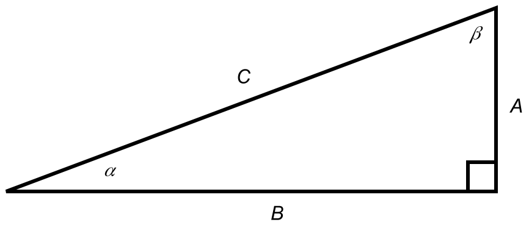

Right triangle with sides A, B, C and angles alpha, beta.

Right triangles are triangles for which one of the three angles is $90^\circ$. Such a triangle has very nice properties. For example, it has a longest edge, which is the edge not adjacent to the right angle. In the figure above, the right angle is labeled with a corner/hook that looks like $\Gamma$. Notice that the edge labeled $C$ is longer than the other two. This edge is called the **hypotenuse** of the triangle.

Pick one of the two other angles and call it $\alpha$. In the figure above, we picked it to be the angle opposite the edge labeled $A$. Because of this, the edge $A$ is said to be **opposite** $\alpha$. Similarly, the edge labeled $B$ is said to be **adjacent**.[^1] Given this naming, it is often useful to relabel the edges as $H$, $O$, and $A$ as in the figure below.

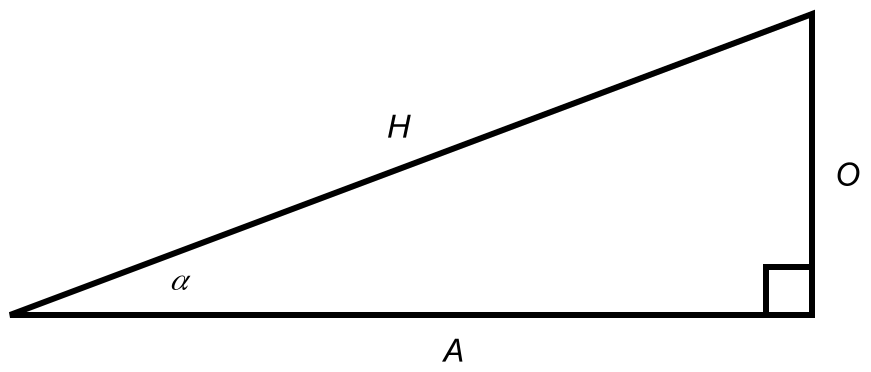

Right triangle relabeled with hypotenuse H, opposite side O, adjacent side A.

Now let’s look at how the lengths of the edges $H$, $O$, and $A$ depend on each other and on the angle $\alpha$. Suppose we fix the length of $A$ and make $O$ bigger or smaller. Then we can clearly see that both $\alpha$ and $H$ get bigger or smaller. We can also switch $A$ and $O$ to come to the same conclusion for $H$, but this time $\alpha$ will do the opposite. Some experimentation with graph paper and a ruler should convince you that the edges satisfy the following relationship:

$$H = \sqrt{A^2 + O^2}.
\tag{1}$$

This rule is called the [Theorem of Pythagoras](https://en.wikipedia.org/wiki/Pythagorean_theorem).

Similarly, the lengths of $A$ and $O$ should suffice to determine $\alpha$: just draw a triangle with some fixed sides $A$ and $O$ and then you will see that it gives some angle $\alpha$ that you can measure with a protractor. If you continue with your experiments, you will also notice that if you double both $A$ and $O$, this does not change the angle $\alpha$. This suggests that there should be a direct relationship between the angle and the ratio $O/A$. Indeed, there is a special function called the tangent function, abbreviated $\tan$, that gives this relation:

$$\tan(\alpha) = \frac{O}{A}.
\tag{2}$$

### Problem 1

Use *geometrical* arguments to show that:

1. $\tan(0) = 0$
2. $\tan(45^\circ) = 1$
3. As $\alpha$ approaches $90^\circ$ from below, $\tan(\alpha)$ grows without bound; explain why $\tan(90^\circ)$ itself is undefined.

Similar considerations imply that there should be special functions to express the angle in terms of the lengths of the hypotenuse and one other edge. They are called the sine, abbreviated $\sin$, and cosine, abbreviated $\cos$:

$$\sin(\alpha) = \frac{O}{H}
\qquad \text{and} \qquad
\cos(\alpha) = \frac{A}{H}.
\tag{3}$$

### Problem 2

Use *geometrical* arguments to show that:

1. $\sin(0)=0$
2. $\sin(90^\circ)=1$
3. $\cos(0)=1$
4. $\cos(90^\circ)=0$

### Problem 3

Use the definitions above to show that

$$\tan(\alpha)=\frac{\sin(\alpha)}{\cos(\alpha)}$$

and check that the special values you demonstrated in Problems 1 and 2 work out. Explain how the $90^\circ$ case agrees with the fact that tangent is undefined there.

Notice that it does not matter which angle we picked in the triangle above, as long as you switch what you are calling adjacent and opposite.

### Problem 4

Going back and calling the other acute angle $\beta$, so that $\alpha+\beta=90^\circ$, show that:

1. $\sin(\beta)=\cos(\alpha)$
2. $\cos(\beta)=\sin(\alpha)$

Right triangles are great because they are *everywhere*.

### Problem 5

Below is an image of the [Burj Khalifa](https://en.wikipedia.org/wiki/Burj_Khalifa). Suppose you are admiring this building from your hotel, “[The Address Downtown](https://en.wikipedia.org/wiki/Address_Downtown),” the other prominent building in the picture, and you know that the horizontal distance to Burj Khalifa is $B=650\,\mathrm{m}$. You want to know its height, so you pull out the sextant you made in Astro and measure the angle to be $\alpha=52^\circ$. For this simplified model, neglect the height of the observer.

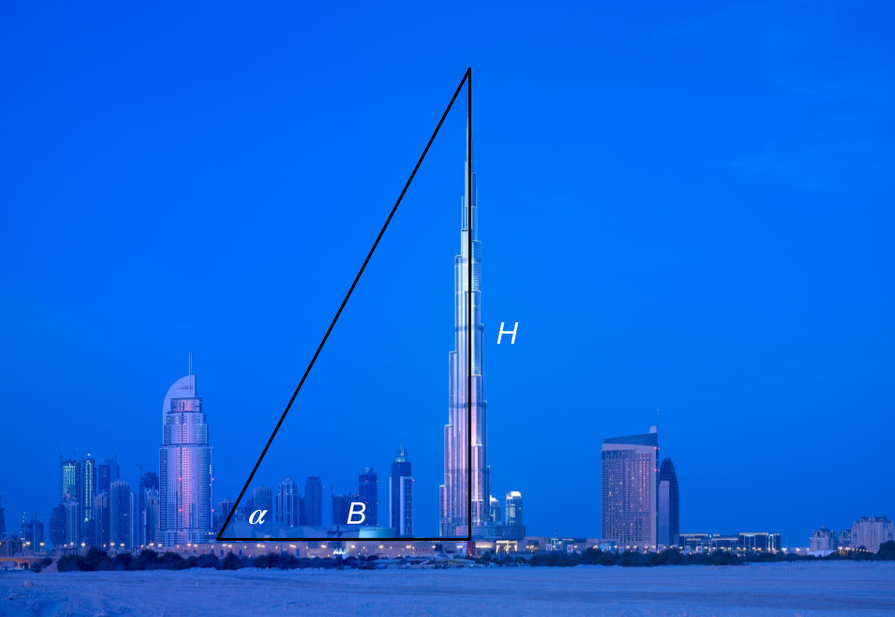

Burj Khalifa height modeled with a right triangle.

1. Write a formula expressing the appropriate trigonometric function of $\alpha$ in terms of $H$ and $B$.
2. Solve your formula for $H$.
3. Calculate the height $H$ numerically.
4. If the angle measurement is uncertain by $\pm 1^\circ$, calculate the heights implied by $51^\circ$ and $53^\circ$. Report the resulting interval and the largest difference from your central estimate.
5. Find the reported height of the Burj Khalifa and calculate the percent difference between it and your estimate.

### Problem 6

The diagram from page 25 of the book shows how a right triangle can be used to measure the width of a river. Choose a point $A$ on the near bank directly opposite a landmark on the far bank. Pace out a baseline $AB$ along the near bank, perpendicular to the river width, and measure the angle at $B$ to the landmark.

1. Explain the procedure in clear steps, including which lengths and angles you measure directly.
2. Suppose $AB=100\,\mathrm{m}$ and your sideways sextant measurement gives an angle of $60^\circ$ at $B$. Write the trigonometric relation connecting the river width $W$ to $AB$, and then calculate $W$.

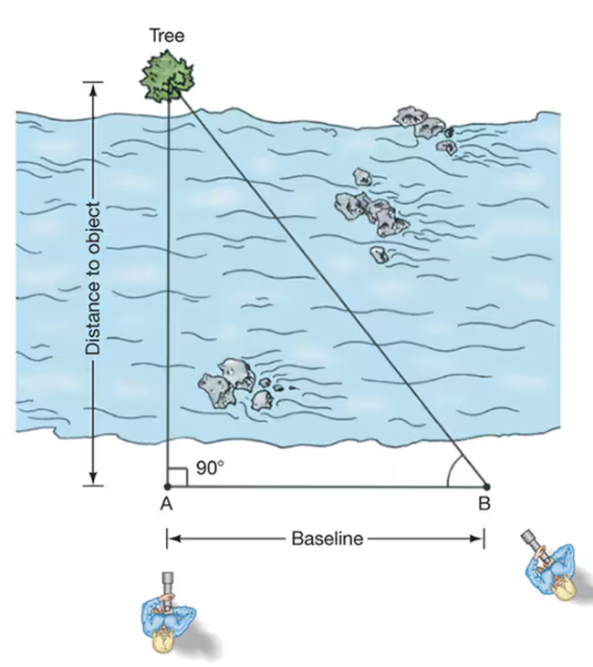

River-width right-triangle setup from page 25 of the book.

### Problem 7

The diagram from page 419 of the book shows the apparent shift of a foreground star relative to distant background stars when viewed from opposite sides of Earth’s orbit. Half of the total apparent shift is the **parallactic angle** $p$. A star is at a distance of one **parsec** when $p$ is one second of arc. The January-to-July observing baseline is $2\,\mathrm{AU}$, while the right triangle used in the calculation has a baseline of $1\,\mathrm{AU}$, the average radius of Earth’s orbit.

1. Convert one arcsecond to degrees and then to radians.
2. Use $\tan(p)=1\,\mathrm{AU}/d$ to express one parsec in AU.
3. Use $1\,\mathrm{AU}=1.5\times 10^{11}\,\mathrm{m}$ to calculate one parsec in meters.
4. It takes light $500\,\mathrm{s}$ to travel $1\,\mathrm{AU}$. How long does light take to travel one parsec? Give your answer in seconds and in years.

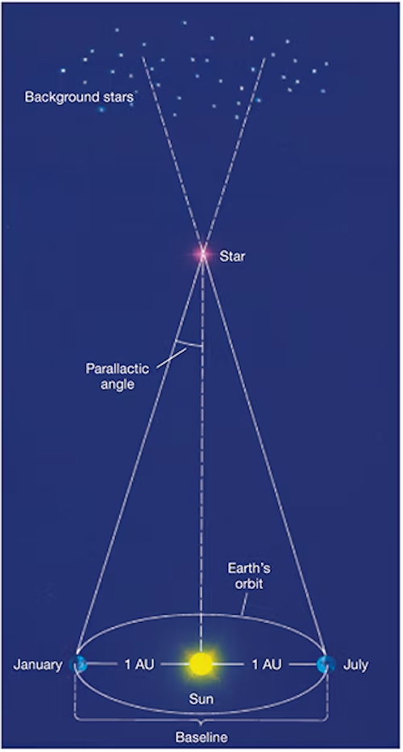

Stellar parallax and the definition of the parsec, from page 419 of the book.

## Radians

A circle of radius $r$ has a circumference $C=2\pi r$. If the radius is $r=1\,\mathrm{m}$, the circle has a circumference of $2\pi\,\mathrm{m}\approx 6.3\,\mathrm{m}$. Note that we needed to specify a unit of measure of length, but whatever units we choose, $r=1$ always gives a circumference of $2\pi$ in the same units.

If we start somewhere on a circle of radius $r$ and follow the arc of the circle to an angle of $45^\circ$, how far have we traveled? This arc length $\ell$ must be an eighth of the circumference, so $\ell=(\pi/4)r$.

Going around the circle once corresponds to going through an angle of $360^\circ$. We see that this corresponds to going through an angle of $2\pi$ in some set of units that is not degrees; we call them **radians**:

[figure not shown]

Figure 1: A radius sweeps counterclockwise around a circle, marking the corresponding arc length in radians. Animation by [Lucas Vieira](https://commons.wikimedia.org/wiki/File:Circle_radians.gif); public domain.

[Explore the interactive Radian Circle laboratory (opens in a new tab)](https://radian-circle.wdlinch3.chatgpt.site/)

$$360^\circ \leftrightarrow 2\pi\,\mathrm{rad},
\qquad
1^\circ \leftrightarrow \frac{\pi}{180}\,\mathrm{rad}\approx 0.0175\,\mathrm{rad},
\qquad
57.296^\circ \leftrightarrow 1\,\mathrm{rad}.$$

Radians have the wonderful property that if an angle $\alpha$ is given in radians, then the length of an arc with this angle on a circle of radius $r$ is

$$\ell = \alpha r
\qquad
(\alpha\ \text{in radians}).$$

### Problem 8

In class you measured the angular size of your outstretched finger. Let $s$ be the width of your finger and $D$ the distance from your eye to your finger. The figure compares the exact isosceles-triangle model with an arc-length approximation.

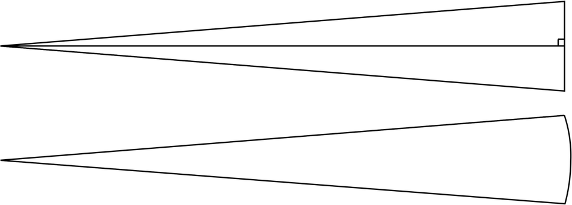

Small-angle triangle and arc-length comparison.

1. Split the isosceles triangle in half and show that the exact angular size is $\alpha_{\mathrm{trig}}=2\arctan\!\left(s/(2D)\right)$.
2. Treat the finger width as an arc length and show that the approximation gives $\alpha_{\mathrm{arc}}=s/D$ radians.
3. Use your measured values of $s$ and $D$ to calculate both angles. Convert them to degrees and report their percent difference.
4. Explain geometrically why the two answers are so close when $D$ is much larger than $s$.

### Problem 9

Consider an isosceles triangle with base $s$, height $h$, equal sides $R$, and apex angle $\alpha$. A circular arc of radius $R$ subtending the same angle has length $\ell=R\alpha$.

1. Bisect the triangle and show that $\tan(\alpha/2)=s/(2h)$ and $R=\sqrt{h^2+(s/2)^2}$.
2. For $h/s=5$, $50$, and $500$, calculate $\alpha$ in radians and the ratio $\ell/s$. Make a table that also gives the percentage by which the arc is longer than the base.
3. Describe how the arc–base discrepancy changes each time $h/s$ increases by a factor of ten.
4. Explain how your results justify replacing a short arc by a straight segment when the triangle is very tall and narrow.

### Problem 10

For a small positive angle measured in radians, geometry suggests that $\sin(\alpha)$, $\alpha$, and $\tan(\alpha)$ should be close.

1. For $\alpha=0.20$, $0.10$, $0.05$, and $0.01$ radians, calculate $\sin(\alpha)$ and $\tan(\alpha)$. For each, also calculate the signed percentage differences

$$E_{\sin}=100\frac{\sin(\alpha)-\alpha}{\alpha},
\qquad
E_{\tan}=100\frac{\tan(\alpha)-\alpha}{\alpha}.$$

2. Use your table to determine which of the approximations $\sin(\alpha)\approx\alpha$ and $\tan(\alpha)\approx\alpha$ are accurate to within $1\%$ at each angle.
3. For $0<\alpha<\pi/2$, draw a unit circle and compare an inscribed triangle, the circular sector, and the outer tangent triangle. Use the comparison to explain why $\sin(\alpha)<\alpha<\tan(\alpha)$.
4. Summarize what happens to both percentage differences as $\alpha$ becomes much smaller than one radian.

## Footnotes

[^1]: You could complain that the hypotenuse is also adjacent to that angle, but that edge is special. It is the longest. The convention is that the long edge is called the hypotenuse and the shorter one is the adjacent edge.